# Analýza modelu CAPM

Finančné trhy a investície

Bc. P.-J. N.

Bc. V. K.

Bc. A. B.

Mgr. Dana Kozáková

(Skupina 02, Tím 07)

12. 07. 2026

## Príklad 1: Získanie dát a odhady beta koeficientov

### 1.1 Načítanie a príprava dát

Využívame dataset obsahujúci denné ceny akcií komponentov indexu **S&P 500** za obdobie *február 2013 – február 2018 (5 rokov, 505 titulov)*. Keďže súbor neobsahuje bezrizikovú sadzbu, predpokladáme $r_f = 0$. Ako trhový index konštruujeme rovnako vážený priemer mesačných výnosov všetkých dostupných titulov.

Mesačné výnosy počítame z cien na konci každého mesiaca (posledný obchodný deň) ako logaritmické výnosy:
$$r_{j,t} =
\ln\left(\frac{P_{j,t}}{P_{j,t-1}}\right)$$

- Dataset po filtrovaní obsahuje **476 akciových titulov** s dennými cenami za obdobie 08. 02. 2013 – 07. 02. 2018 (≈ 60 mesiacov).
- Vyradených bolo 29 titulov s menej než 1 200 obchodnými dňami.
- Celkový počet mesačných pozorovaní je **28 560**.

### 1.2 Vizualizácia trhového portfólia a výnosov

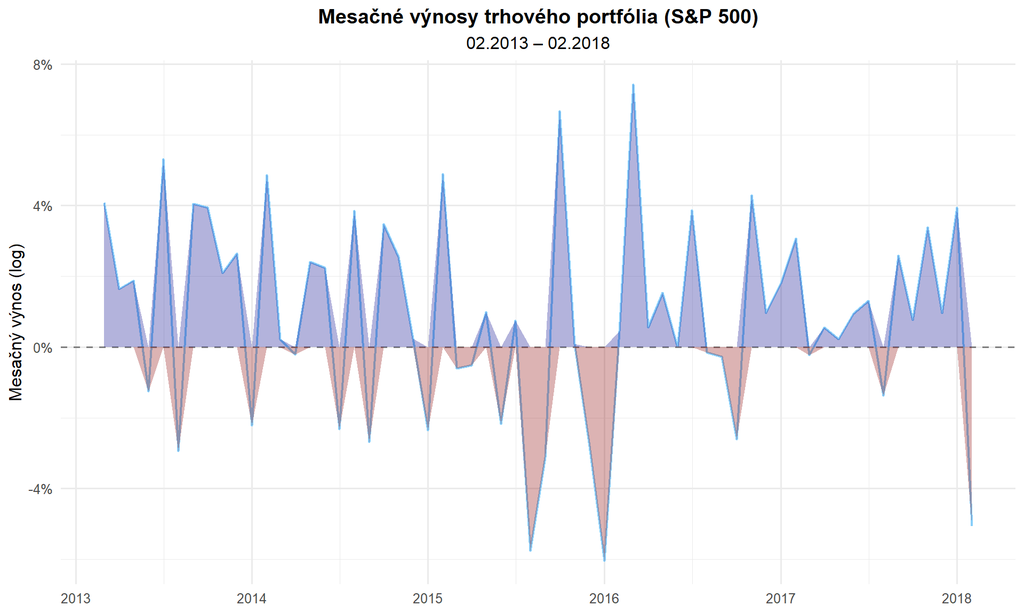

Vývoj mesačného výnosu trhového portfólia

Trhové portfólio vykazuje prevažne **kladné** mesačné výnosy, čo odráža dlhodobo rastúci trend amerického akciového trhu v sledovanom období.

Výraznejšie poklesy sú viditeľné v auguste–septembri 2015 a začiatkom roka 2016, čo zodpovedá globálnemu výpredaju spojenému s pádom čínskeho akciového trhu a obavami o spomalenie čínskej ekonomiky.

Top 5 a Bottom 5 titulov podľa priemerného mesačného výnosu

| Name | Priemer | Medián | SD | Min | Max | Šikmosť | Špicatosť |
| --- | --- | --- | --- | --- | --- | --- | --- |
| NVDA | 0.0482 | 0.0343 | 0.0922 | -0.1180 | 0.3250 | 0.8367 | 3.6396 |
| NFLX | 0.0381 | 0.0406 | 0.1198 | -0.2358 | 0.3422 | 0.1514 | 3.0362 |
| ALGN | 0.0335 | 0.0328 | 0.0778 | -0.1605 | 0.2492 | -0.0005 | 3.3033 |
| EA | 0.0325 | 0.0255 | 0.0840 | -0.1689 | 0.2666 | 0.4955 | 3.5005 |
| AVGO | 0.0323 | 0.0276 | 0.0757 | -0.1163 | 0.2365 | 0.4783 | 3.1249 |
| MAT | -0.0146 | -0.0087 | 0.0912 | -0.2290 | 0.2566 | 0.2885 | 3.9066 |
| DISCK | -0.0180 | -0.0055 | 0.1163 | -0.6715 | 0.1578 | -2.9816 | 17.7708 |
| DISCA | -0.0192 | -0.0074 | 0.1152 | -0.6673 | 0.1627 | -2.9830 | 17.9148 |
| RRC | -0.0295 | -0.0358 | 0.1136 | -0.2273 | 0.3108 | 0.7558 | 4.1159 |
| CHK | -0.0324 | -0.0312 | 0.1659 | -0.4709 | 0.5113 | 0.6024 | 5.0562 |

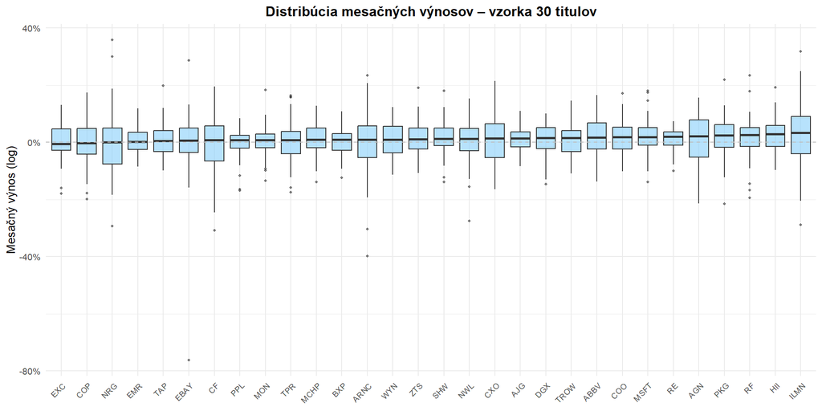

Distribúcia mesačných výnosov – náhodná vzorka 30 titulov

Väčšina titulov vykazuje mediánový výnos blízky nule s relatívne symetrickým rozložením, čo je konzistentné s predpokladmi CAPM. Viditeľné sú však výrazné odľahlé hodnoty u niektorých titulov, čo naznačuje občasné extrémne mesačné pohyby.

Keďže dataset neobsahuje bezrizikovú úrokovú mieru, predpokladáme $r_f = 0$ počas celého sledovaného obdobia. Tento predpoklad zodpovedá prostrediu nízkych úrokových sadzieb po finančnej kríze 2008.

### 1.3 Odhad beta koeficientov a charakteristické krivky

Pre každý titul odhadneme OLS regresiou tzv. **charakteristickú krivku** CAPM:
$$r_j - r_f = \alpha_j
+ \beta_j (r_m - r_f) + \varepsilon_j$$

- Beta koeficienty odhadnuté OLS metódou sa pohybujú v intervale **0.014** až **2.664**.
- V súbore je **238 defenzívnych titulov** ($\beta < 1$) a **238 agresívnych titulov** ($\beta > 1$).
- Extrémne nízke hodnoty bety naznačujú tituly takmer nezávislé od pohybu trhu, zatiaľ čo hodnoty okolo 2.5–2.7 indikujú výrazne vyššiu volatilitu ako celý trh.

Top 5 (najvyššia β) a Bottom 5 (najnižšia β) titulov

| Titul | Alpha | Beta | SE(Beta) | t(Beta) | R-squared |
| --- | --- | --- | --- | --- | --- |
| DLR | 0.0072 | 0.0135 | 0.2660 | 0.051 | 0.000 |
| SO | -0.0012 | 0.0612 | 0.1909 | 0.321 | 0.002 |
| ED | 0.0035 | 0.0682 | 0.2291 | 0.298 | 0.002 |
| CAG | 0.0000 | 0.1010 | 0.2757 | 0.366 | 0.002 |
| WEC | 0.0050 | 0.1390 | 0.2331 | 0.596 | 0.006 |
| DVN | -0.0265 | 2.2741 | 0.4504 | 5.049 | 0.305 |
| MRO | -0.0333 | 2.4269 | 0.4766 | 5.092 | 0.309 |
| AMD | 0.0033 | 2.5375 | 0.5965 | 4.254 | 0.238 |
| FCX | -0.0327 | 2.6196 | 0.7527 | 3.480 | 0.173 |
| URI | -0.0038 | 2.6639 | 0.3865 | 6.892 | 0.450 |

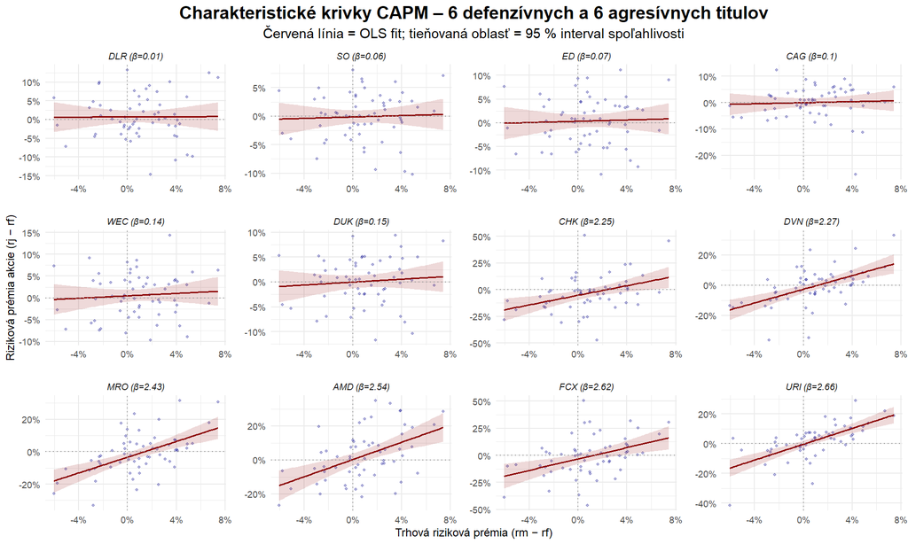

Charakteristické krivky pre 6 defenzívnych a 6 agresívnych titulov

### 1.4 Test nulovosti konštanty $\alpha$ (hladina 5 %)

Podľa CAPM by mala byť konštanta $\alpha_j$ štatisticky nevýznamná pre všetky tituly — výnos akcie by mal byť plne vysvetlený trhovým rizikom. Pre každý titul testujeme:
$$H_0: \alpha_j =
0 \quad \text{vs} \quad H_1: \alpha_j \neq 0$$

T-test na hladine 5 %

| Výsledok | Počet titulov |
| --- | --- |
| Nezamietame H₀ | 441 |
| Zamietame H₀ | 35 |

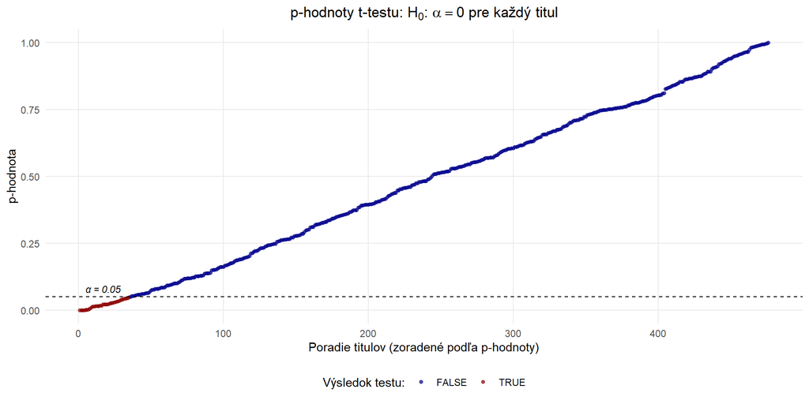

## Příklad 2: Testování platnosti CAPM

### 2.1 Seřazení a vytvoření portfólii na základě $\beta$

Cenné papíry seřadíme podle odhadované bety a rozdělíme je do **10 decilů** (portfolií). $\beta$ každého portfolia je aritmetický průměr individuálních $\beta$ jednotlivých cenných papírů v daném decilu. Výnosnost portfolia je průměrná $\alpha$ cenných papírů v daném decilu.

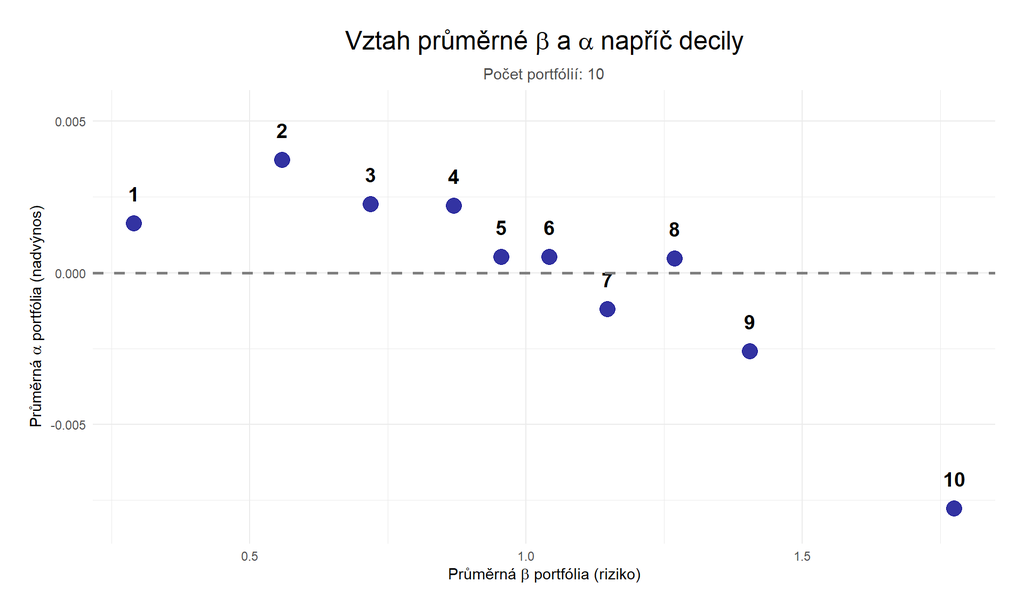

### 2.2 Přidání security market line

**Security Market Line (SML)** zachycuje teoretický lineární vztah mezi systematickým rizikem ($\beta$) a očekávaným nadvýnosem portfolia:
$$r_{pi} - r_f = \gamma_0 + \gamma_1
\beta_{pi} + \varepsilon_{pi}$$

Podle modelu CAPM by mělo platit: $\gamma_0 = 0$ a $\gamma_1 = \bar{r}_m - r_f$ (pozorovaná trhová prémie).

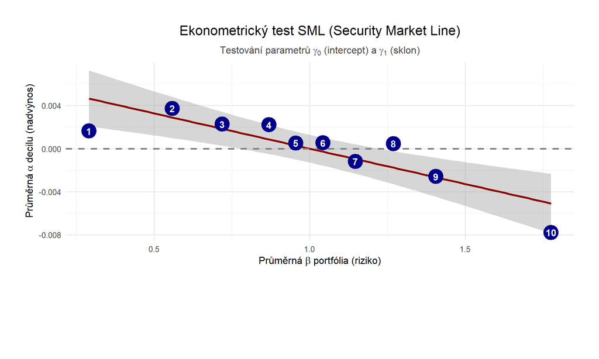

### Statistické testy

#### **WALDŮV TEST** ($\gamma_0$ = 0)

Waldův test

| Res.Df | RSS | Df | Sum of Sq | F | Pr(>F) |
| --- | --- | --- | --- | --- | --- |
| 9 | 8.55e-05 | NA | NA | NA | NA |
| 8 | 2.49e-05 | 1 | 6.07e-05 | 19.53154 | 0.0022281 |

Na základě Waldova testu zamítáme nulovou hypotézu, že $\gamma_0 = 0$ na hladině významnosti 5 %. Hodnota p-hodnoty je 0.00223. Podle teorie modelu CAPM by tento parametr měl být statisticky nevýznamný. Jeho významnost naznačuje, že model systematicky chybuje v ocenění nadvýnosu.

#### **TEST LINEARITY** ($\gamma_2$ = 0): Je vztah lineární? (Významnost $\beta^2$)

Test linearity

| Parameter | Estimate | Std. Error | t value | Pr(>\|t\|) |
| --- | --- | --- | --- | --- |
| γ0 (intercept) | 0.0007 | 0.0016 | 0.4231 | 0.6849 |
| γ1 (sklon – beta) | 0.0071 | 0.0032 | 2.2509 | 0.0591 |
| γ₂ (kvadratický člen – beta^2) | -0.0067 | 0.0015 | -4.4509 | 0.0030 |

Koeficient u $\beta^2$ je statisticky významný (p = 0.0030), proto zamítáme nulovou hypotézu o linearitě. To naznačuje, že vztah mezi výnosem a betou není lineární a SML model je pravděpodobně špatně specifikován.

**Test sklonu parametru** $\gamma_1$: Odhadnutá hodnota $-0.00655$ vykazuje záporný sklon SML, což je v rozporu s předpokladem CAPM, kde by $\gamma_1$ měla odpovídat kladné tržní rizikové prémii. Tento výsledek naznačuje, že vztah mezi výnosem a systematickým rizikem není v souladu s teoretickým očekáváním CAPM.

V období 2013-2018 model CAPM na zkoumaném vzorku selhává. Pozorujeme tzv. Low-Beta anomálii, kdy bezečnější tituly překonaly očekávání a rizikové tituly zaostaly.

Koeficienty základního SML modelu

| Parameter | Estimate | Std. Error | t value | Pr(>\|t\|) |
| --- | --- | --- | --- | --- |
| γ₀ (intercept) | 0.0066 | 0.0015 | 4.4194 | 0.0022 |
| γ₁ (sklon – beta) | -0.0066 | 0.0014 | -4.7864 | 0.0014 |

### 2.3 Test CAPM podle Fama a MacBeth

Kromě základní specifikace SML testujeme také rozšířenou specifikaci:

$$r_j = \delta_1 + \delta_2 \beta_j + \delta_3 \beta_j^2 + \delta_4
\sigma^2_{\varepsilon_j} + \varepsilon_j$$

Podle modelu CAPM by mělo platit: - $\delta_3 = 0$ (linearita) - $\delta_4 = 0$ (nesystematické riziko nemá vliv) - $\delta_2 > 0$ (kladná riziková prémie)

VÝSLEDKY TESTU FAMA-MACBETH

| Parameter | Estimate | Std. Error | t value | Pr(>\|t\|) |
| --- | --- | --- | --- | --- |
| δ1 (intercept) | 0.0042 | 0.0036 | 1.1569 | 0.2913 |
| δ2 (beta) | 0.0036 | 0.0040 | 0.9027 | 0.4015 |
| δ3 (beta^2) | -0.0043 | 0.0023 | -1.9025 | 0.1058 |
| δ4 (σ^2) | -39.7227 | 41.1724 | -0.9648 | 0.3719 |

WALDŮV TEST PRO SPOLEČNOU NULOVOU HYPOTÉZU (δ3 = δ4 = 0)

| Res.Df | RSS | Df | Sum of Sq | F | Pr(>F) |
| --- | --- | --- | --- | --- | --- |
| 8 | 0 | NA | NA | NA | NA |
| 6 | 0 | 2 | 0 | 10.3672 | 0.0113 |

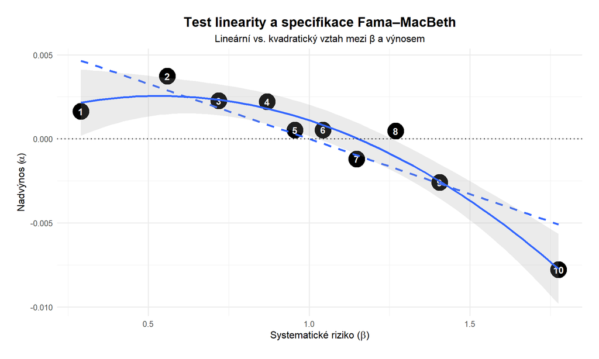

**Závěr:** Výsledky ukazují, že zatímco individuální nelineární efekty nejsou jednoznačně významné, společný test naznačuje odchylku od teoretické specifikace CAPM. Model tedy není plně konzistentní s předpoklady lineární SML.

## Príklad 3: Štrukturálne zlomy v CAPM

Testujeme, či sa $\beta$ koeficient zmenil v **posledných 24 mesiacoch** vzorky. Charakteristickú krivku rozšírime o interakčný člen so slope dummy $D_t$:
$$r_j - r_f = \alpha_j + \beta_j(r_m - r_f) +
\delta_j \cdot D_t \cdot (r_m - r_f) + \varepsilon_j$$

- kde $D_t = 1$ pre posledných 24 mesiacov, inak $D_t = 0$.
- Ak je $\delta_j$ štatisticky významné, $\beta$ sa zmenila.

Na testovanie použijeme 2 testy:

- **Chowov test štrukturálneho zlomu**
- **Chowov predpovedný test**

### 3.1a Test štrukturálneho zlomu v $\beta$ koeficientoch

**Chowov test štrukturálneho zlomu** rozdelí vzorku v bode zlomu na dve časti a porovná reziduálne súčty štvorcov spojeného modelu ($S_0$) s reziduálnymi súčtami štvorcov dvoch samostatných modelov ($S_1$, $S_2$).

- F-štatistika má tvar:
  $$F = \frac{(S_0 -
  S_1 - S_2)/k}{(S_1 + S_2)/(n_1 + n_2 - 2k)} \sim F(k,\ n_1 + n_2 -
  2k)$$
- $H_0: \beta_j^{(1)} = \beta_j^{(2)}$

Bod zlomu je 03. 2016, čím vznikajú dve obdobia: $36$ mesiacov (pred zlomom) a $24$ mesiacov (po zlome).

Chowov test štrukturálneho zlomu na hladine 5 %

| Výsledok | Počet titulov |
| --- | --- |
| Nezamietame H₀ | 440 |
| Zamietame H₀ | 36 |

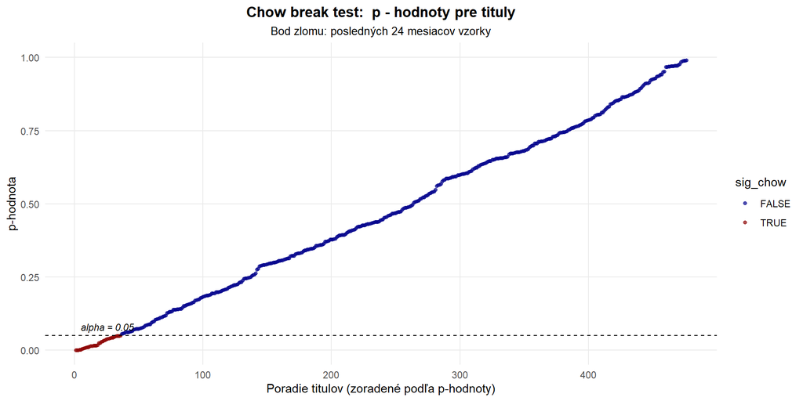

Na hladine významnosti 5 % zamietame stabilitu $\beta$ koeficientu u **36 titulov** (7.6 % zo všetkých 476 titulov). Pre výraznú väčšinu akcií teda nemáme štatistický dôkaz o štrukturálnom zlome v $\beta$ v posledných 24 mesiacoch vzorky. Tituly so zisteným zlomom pochádzajú z rôznych sektorov – od maloobchodu (ORLY, AZO, TSCO) cez zdravotníctvo (CAH, MCK, CVS) až po technológie (NVDA, MA, FISV), čo naznačuje skôr sektorovo špecifické zmeny ako systematický trhový jav.

### 3.1b Chowov predpovedný test

**Chowov predpovedný test** odhaduje model len na prvom období a meria, ako dobre predpovedá druhé obdobie. F-štatistika má tvar:

$$F = \frac{(S_0 - S_1)/n_2}{S_1/(n_1 -
k)} \sim F(n_2,\ n_1 - k)$$

kde $S_0$ je RSS z modelu odhadnutého na celej vzorke, $S_1$ je RSS z modelu odhadnutého len na prvom období, $n_1$, $n_2$ sú počty pozorovaní pred a po zlome a $k$ je počet parametrov modelu.

Chowov predpovedného testu na hladine 5 %

| Záver testu | Počet titulov |
| --- | --- |
| Nezamietame H0 | 391 |
| Zamietame H0 | 85 |

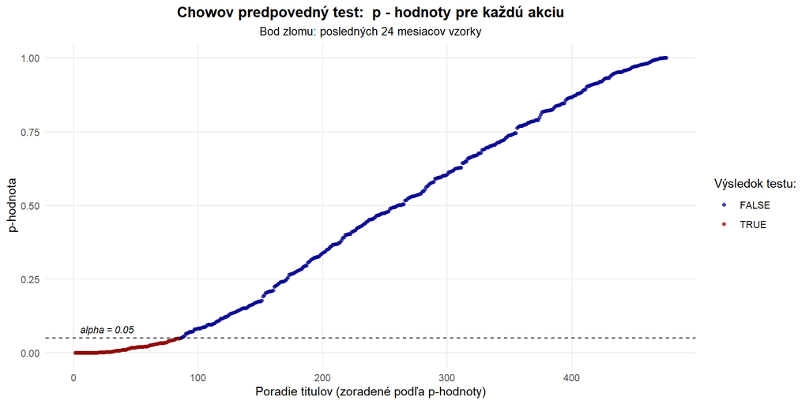

Chowov predpovedný test zamietol stabilitu modelu u **85 titulov** (17.9 %), čo je výrazne viac ako pri štrukturálnom teste (36 titulov). Rozdiel medzi testami: štrukturálny test testuje len zmenu koeficientov, predpovedný test je citlivejší – zamietne aj keď sa zmení rozptyl reziduálov alebo iná charakteristika modelu. Vyšší počet zamietnutí pri predpovednom teste teda naznačuje, že pre mnohé tituly sa síce $\beta$ štatisticky nezmenila, ale model z prvého obdobia predpovedá druhé obdobie so systematickou chybou.

### 3.2 Platnost CAPM modelu (security market line) na dvoch obdobiach

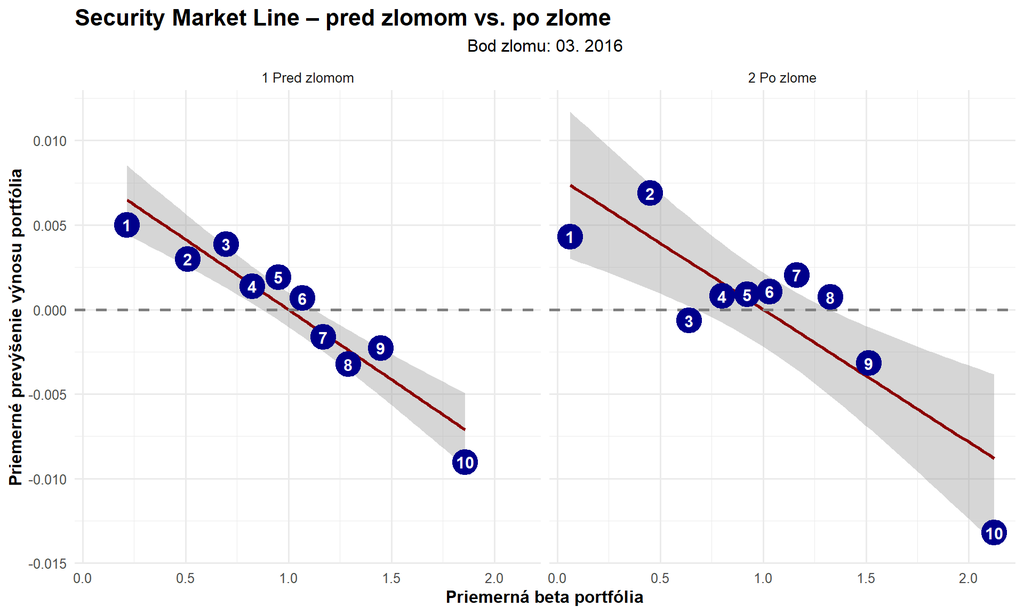

Koeficienty SML pre dve obdobia

| Obdobie | Parameter | Estimate | Std. Error | t value | Pr(>\|t\|) |
| --- | --- | --- | --- | --- | --- |
| Pred zlomom | γ₀ (intercept) | 0.0083 | 0.0011 | 7.7138 | 0.0001 |
| Pred zlomom | γ₁ (sklon – beta) | -0.0083 | 0.0010 | -8.4917 | 0.0000 |
| Po zlome | γ₀ (intercept) | 0.0079 | 0.0020 | 3.9628 | 0.0042 |
| Po zlome | γ₁ (sklon – beta) | -0.0079 | 0.0017 | -4.5315 | 0.0019 |

SML vykazuje v **oboch obdobiach negatívny sklon**, čo potvrdzuje záver z Príkladu 2 o prítomnosti Low-Beta anomálie počas celého sledovaného obdobia.

**Pred zlomom** (02.2013 – 02.2016): $\hat{\gamma}_0 = 0.00827$ ($p = 10^{-4}$), $\hat{\gamma}_1 = -0.00828$ ($p = 0$) – oba koeficienty štatisticky významné.

**Po zlome** (03.2016 – 02.2018): $\hat{\gamma}_0 = 0.00786$ ($p = 0.0042$), $\hat{\gamma}_1 = -0.00785$ ($p = 0.0019$) – oba koeficienty štatisticky významné.

Hodnoty $\gamma_0$ a $\gamma_1$ sú v oboch obdobiach veľmi podobné, čo naznačuje, že anomália nie je sústredená len v jednej perióde, ale ide o systematický jav. CAPM teda zlyháva konzistentne v celom sledovanom období 2013–2018.

### 3.3 Asymetria beta koeficientu (dual-beta model)

Štandardný CAPM predpokladá, že beta koeficient je rovnaký bez ohľadu na smer pohybu trhu. Testujeme, či akcie reagujú inak pri **raste** ($r_{m,t} - r_f > 0$) a inak pri **poklese** trhu ($r_{m,t} - r_f \leq 0$). Charakteristickú krivku reformulujeme zavedením indikátorovej premennej:

$$D_t^{-} = \begin{cases} 1 & \text{ak
} r_{m,t} - r_f \leq 0 \\ 0 & \text{inak} \end{cases}$$

**Dual-beta model (testovacia forma):**
$$r_{j,t} - r_f = \alpha_j + \beta_j^{+}(r_{m,t} -
r_f) + \gamma_j \cdot D_t^{-}(r_{m,t} - r_f) +
\varepsilon_{j,t}$$

kde $\beta_j^{+}$ je $\beta$ pri raste trhu a $\beta_j^{-} = \beta_j^{+} + \gamma_j$ je $\beta$ pri poklese trhu. Test asymetrie sa tak redukuje na:
$$H_0: \gamma_j
= 0 \quad \text{(}\beta^+ = \beta^-\text{, symetria)}\quad \text{vs}
\quad H_1: \gamma_j \neq 0$$

Z celkových ~60 mesiacov sledovaného obdobia bolo **40 bull mesiacov** ($r_m - r_f > 0$) a **20 bear mesiacov** ($r_m - r_f \leq 0$). Sledované obdobie 2013–2018 bolo prevažne rastúcim trhom, čo znižuje štatistickú silu pre odhad $\beta^-$ — tento fakt je nutné zohľadniť pri interpretácii výsledkov.

Výsledky testu H₀: γⱼ = 0 (β⁺ = β⁻) na hladine 5 %

| Záver testu | Počet titulov | Podiel (%) |
| --- | --- | --- |
| Nezamietame H₀ | 457 | 96 |
| Zamietame H₀ | 19 | 4 |

Top 10 titulov s najvýraznejšou asymetriou β⁺ ≠ β⁻ (p < 0,05)

| Titul | α | β⁺ (bull) | β⁻ (bear) | β⁻ − β⁺ | γ | SE(γ) | t(γ) | p-value |
| --- | --- | --- | --- | --- | --- | --- | --- | --- |
| MU | 0.0543 | 0.0734 | 3.8401 | 3.7667 | 3.7667 | 1.5599 | 2.415 | 0.0190 |
| SIG | -0.0481 | 2.3100 | -0.9726 | -3.2826 | -3.2826 | 1.4672 | -2.237 | 0.0292 |
| AAP | -0.0395 | 2.5657 | -0.5143 | -3.0799 | -3.0799 | 1.0532 | -2.924 | 0.0049 |
| CTSH | -0.0290 | 2.1473 | -0.7526 | -2.8999 | -2.8999 | 0.8819 | -3.288 | 0.0017 |
| WDC | 0.0286 | 0.0291 | 2.6149 | 2.5858 | 2.5858 | 1.2218 | 2.116 | 0.0387 |
| SNI | -0.0280 | 2.0525 | -0.0092 | -2.0617 | -2.0617 | 0.9155 | -2.252 | 0.0282 |
| FLR | -0.0373 | 2.3617 | 0.3240 | -2.0377 | -2.0377 | 0.7925 | -2.571 | 0.0128 |
| ORLY | -0.0151 | 1.7614 | -0.2083 | -1.9697 | -1.9697 | 0.6454 | -3.052 | 0.0035 |
| TSCO | -0.0279 | 2.0665 | 0.1870 | -1.8795 | -1.8795 | 0.9211 | -2.040 | 0.0459 |
| DE | 0.0236 | -0.0026 | 1.7938 | 1.7964 | 1.7964 | 0.6878 | 2.612 | 0.0115 |

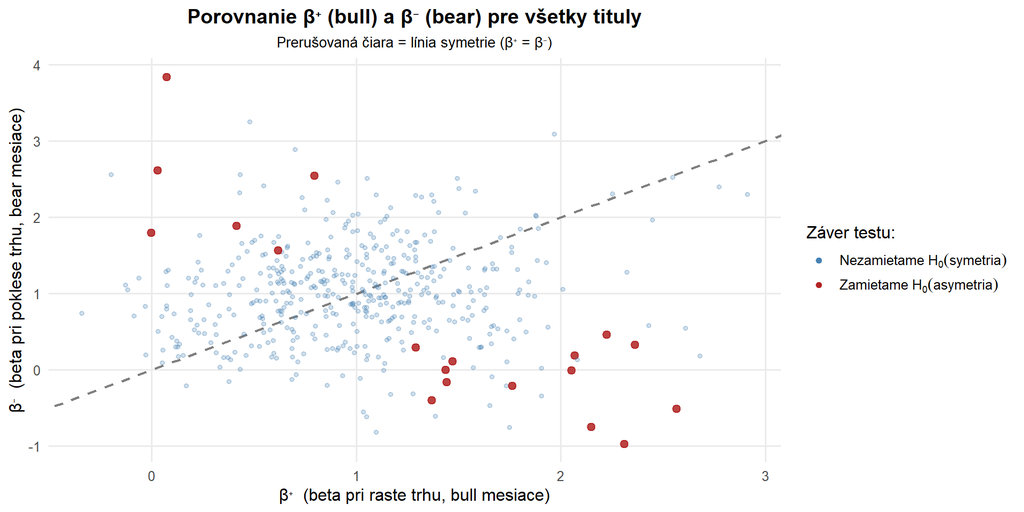

Porovnanie bull-bety a bear-bety pre všetky tituly

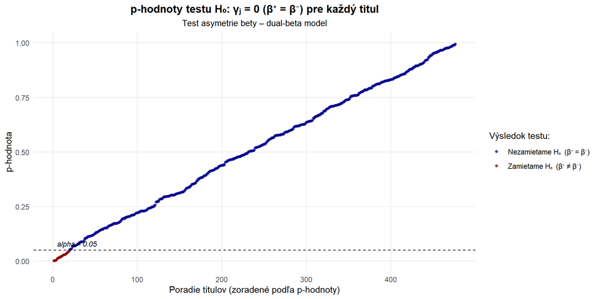

p-hodnoty testu H₀: γⱼ = 0 pre každý titul (zoradené vzostupne)

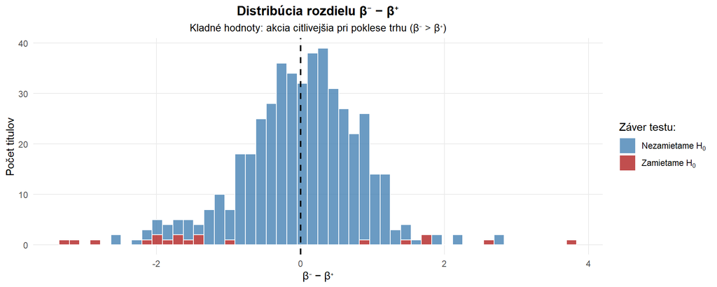

Distribúcia rozdielu β⁻ − β⁺ pre všetky tituly

### 3.4 Security Market Line v období rastu a poklesu trhu

Na základe dual-beta modelu z predchádzajúcej sekcie odhadujeme **Security Market Line samostatne pre bull a bear obdobia**. Postup je analogický s príkladom 2 a sekciou 3.2. , avšak namiesto rozdelenia vzorky v čase rozdeľujeme pozorovania podľa **smeru pohybu trhu**:

- **Bull SML** — odhadnutá výhradne na mesiacoch, kde $r_{m,t} - r_f > 0$, s betami odhadnutými z tých istých mesiacov ($\beta^+$)
- **Bear SML** — odhadnutá výhradne na mesiacoch, kde $r_{m,t} - r_f \leq 0$, s betami odhadnutými z tých istých mesiacov ($\beta^-$)

Pre každý režim testujeme platnosť CAPM:
$$r_{pi} - r_f = \gamma_0 + \gamma_1 \beta_{pi} +
\varepsilon_{pi}$$
$$H_0^{(1)}:
\gamma_0 = 0 \qquad H_0^{(2)}: \gamma_1 = \bar{r}_m^{\text{režim}} -
r_f$$

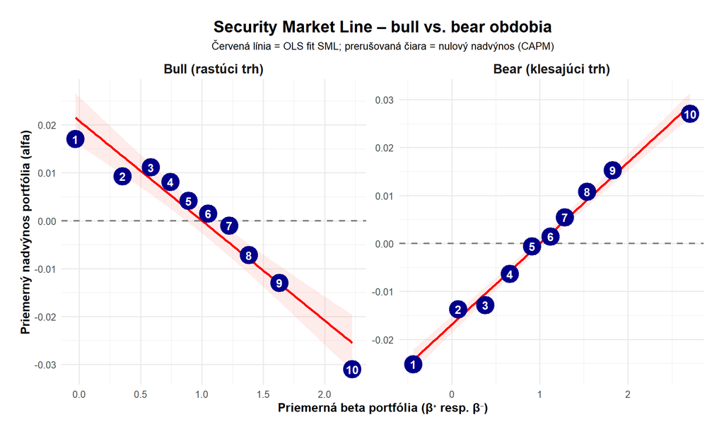

Security Market Line – bull vs. bear obdobia

Koeficienty SML pre bull a bear obdobia

| Režim | Parameter | Estimate | Std. Error | t value | Pr(>\|t\|) |
| --- | --- | --- | --- | --- | --- |
| Bull (rastúci trh) | γ₀ (intercept) | 0.0208 | 0.0022 | 9.5176 | 0 |
| Bull (rastúci trh) | γ₁ (sklon – beta) | -0.0208 | 0.0019 | -11.2386 | 0 |
| Bear (klesajúci trh) | γ₀ (intercept) | -0.0169 | 0.0008 | -22.1024 | 0 |
| Bear (klesajúci trh) | γ₁ (sklon – beta) | 0.0169 | 0.0006 | 29.2842 | 0 |

Waldov test H₀: γ₀ = 0 pre bull a bear SML

|  | Režim | Df | Sum of Sq | F | Pr(>F) |
| --- | --- | --- | --- | --- | --- |
| 2…1 | Bull (rastúci trh) | 1 | 0.0012 | 90.5844 | 0 |
| 2…2 | Bear (klesajúci trh) | 1 | 0.0012 | 488.5155 | 0 |

Porovnanie SML parametrov: bull vs. bear obdobia

| Charakteristika | Bull (rastúci trh) | Bear (klesajúci trh) |
| --- | --- | --- |
| Počet mesiacov v režime | 40 | 20 |
| Počet titulov (min. 5 obs.) | 476 | 476 |
| Pozorovaná trhová prémia r̄ₘ | 2.438 % | -2.235 % |
| γ₀ (intercept) | 0.02081 | -0.01691 |
| p-hodnota γ₀ | 0 | 0 |
| Waldov test γ₀ = 0 (p-hodnota) | 0 | 0 |
| γ₁ (sklon SML) | -0.02081 | 0.01692 |
| p-hodnota γ₁ | 0 | 0 |
| Smer SML | Záporný | Kladný |
| Záver: γ₀ = 0? | Zamietame H₀ | Zamietame H₀ |

**Bull SML ($\hat{\gamma}_0 = 0.02081$, $\hat{\gamma}_1 = -0.02081$):** Waldov test zamietol nulovosť interceptu ($p = 0$). Sklon SML je záporný, čo je v rozpore s predpokladom CAPM aj v rastúcom trhu — Low-Beta anomália pretrváva aj v bull obdobiach.